# R Integration with Financial Data Sources

Automating Live Financial Data Feeds

# Introduction: What is R Integration?

R can directly connect to live external resources:

- Stock Market Data

- Economic Indicators

- Financial APIs

- Online Data Sources

**Why do analysts use this?** - Download data automatically with code instead of pointing-and-clicking. - Build completely reproducible research scripts. - Avoid slow, error-prone manual Excel downloads.

# 1. quantmod: Stock Data & Traditional Charts

### Purpose

Used for downloading stock prices, creating native financial charts, and quickly applying traditional technical analysis indicators.

### Load Package

```r
library(quantmod)
```

### Download Apple Stock Data

```r
getSymbols("AAPL")
```

```
[1] "AAPL"
```

### View Data Structure

```r
head(AAPL)
```

```
           AAPL.Open AAPL.High AAPL.Low AAPL.Close AAPL.Volume AAPL.Adjusted
2007-01-03  3.081786  3.092143 2.925000   2.992857  1238319600      2.508588
2007-01-04  3.001786  3.069643 2.993571   3.059286   847260400      2.564270
2007-01-05  3.063214  3.078571 3.014286   3.037500   834741600      2.546009
2007-01-08  3.070000  3.090357 3.045714   3.052500   797106800      2.558581
2007-01-09  3.087500  3.320714 3.041071   3.306071  3349298400      2.771122
2007-01-10  3.383929  3.492857 3.337500   3.464286  2952880000      2.903737
```

### Plot Stock Prices Inline

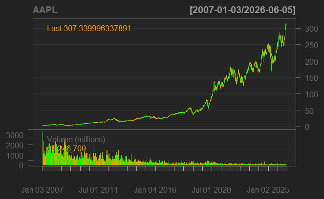

```r
chartSeries(AAPL)
```

> **Key Point:** `quantmod` = Quick Financial Data + Native Financial Charts

# 2. tidyquant: The Tidyverse for Finance

### Purpose

Combines the power of **Tidyverse** data manipulation with **Financial Data structures**. It turns financial data into data frames (`tibbles`) that work flawlessly with familiar `dplyr` and `ggplot2` syntax.

```r
install.packages("tidyquant")
```

[output not shown]

[output not shown]

### Load Package

```r
library(tidyquant)
```

### Download Stock Data into a Tidy Data Frame

```r
apple <- tq_get(
  "AAPL",
  from = "2025-01-01"
)

head(apple)
```

| symbol | date | open | high | low | close | volume | adjusted |
| --- | --- | --- | --- | --- | --- | --- | --- |
| AAPL | 2025-01-02 | 248.93 | 249.10 | 241.82 | 243.85 | 55740700 | 242.3019 |
| AAPL | 2025-01-03 | 243.36 | 244.18 | 241.89 | 243.36 | 40244100 | 241.8150 |
| AAPL | 2025-01-06 | 244.31 | 247.33 | 243.20 | 245.00 | 45045600 | 243.4446 |
| AAPL | 2025-01-07 | 242.98 | 245.55 | 241.35 | 242.21 | 40856000 | 240.6723 |
| AAPL | 2025-01-08 | 241.92 | 243.71 | 240.05 | 242.70 | 37628900 | 241.1592 |
| AAPL | 2025-01-10 | 240.01 | 240.16 | 233.00 | 236.85 | 61710900 | 235.3464 |

### Calculate Average Closing Price using dplyr Syntax

```r
library(dplyr)
```

```r
apple %>%
  summarise(
    Avg_Close = mean(close)
  )
```

| Avg_Close |
| --- |
| 243.6841 |

> **Key Point:** `tidyquant` = Comprehensive Financial Analysis using Tidyverse Workflows

# 3. httr: Connecting to Custom Financial Web APIs

### Purpose

Connects R to external Web APIs. This is essential for sourcing unstructured data not covered by financial packages, such as live exchange rates, cryptocurrency tickers, and macroeconomic databases.

### Load Package

```r
library(httr)
```

### Make a Live API Request (Free Exchange Rate API)

```r
response <- GET(
  "https://api.exchangerate-api.com/v4/latest/USD"
)

response
```

```
Response [https://api.exchangerate-api.com/v4/latest/USD]
  Date: 2026-06-08 03:52
  Status: 200
  Content-Type: application/json
  Size: 2.23 kB
```

### Convert Raw API JSON Response to Text

```r
content(response, "text")
```

```
[1] "{\"provider\":\"https://www.exchangerate-api.com\",\"WARNING_UPGRADE_TO_V6\":\"https://www.exchangerate-api.com/docs/free\",\"terms\":\"https://www.exchangerate-api.com/terms\",\"base\":\"USD\",\"date\":\"2026-06-08\",\"time_last_updated\":1780876801,\"rates\":{\"USD\":1,\"AED\":3.67,\"AFN\":63…
```

> **Key Point:** `httr` = Connect R directly to any custom web API or data stream

```r
library(httr)
library(jsonlite)

response <- GET(
  "https://api.exchangerate-api.com/v4/latest/USD"
)

data <- fromJSON(content(response, "text"))

str(data)
```

[output not shown]

[output cut: 53 more lines]

[output not shown]

# Core Concept Workflow

### The Traditional Old Way (Inefficient)

```
Website → Manually Download CSV → Open Excel → Copy/Paste/Clean → Import into R
```

### The Automated R Way (Productive)

```
R Script → Automatically Fetch Data → Analyze Instantly → Live Visualization
```

# Lesson Summary

| Package | Core Technical Purpose |
| --- | --- |
| **`quantmod`** | Quick market data scraping and immediate native charting. |
| **`tidyquant`** | Converts market data into neat data frames for Tidyverse flows. |
| **`httr`** | Connects R directly to custom HTTP REST APIs (Crypto, FX, Economics). |

**Why should a quantitative analyst use tools like quantmod, tidyquant, and httr?** > *Answer:* These packages allow R to bypass manual downloads and pipe web-hosted financial data directly into memory. This eliminates Excel manual errors, automates recurring data refreshes, and ensures the entire analytics workflow is perfectly reproducible.